# Políticas de Extensão Rural no Brasil · Da Difusão à Participação

Extensão Rural

Prof. Dr. Luiz Diego Vidal Santos

## Abertura Visão Geral da Aula

Roteiro da aula Tópicos principais

- 1 Contexto Histórico e Estrutura Agrária
- 2 Modelo Difusionista e seus Problemas
- 3 Extensão Rural Agroecológica
- 4 Andragogia de Knowles
- 5 PNATER, PRONATER e ATER Digital

Objetivo da aula Da difusão à participação

Analisar a evolução das políticas de extensão rural no Brasil, do modelo difusionista às abordagens participativas, agroecológicas e andragógicas.

Lei 4.504/64 Lei 12.188/2010 Andragogia

Da transferência unilateral de pacotes tecnológicos ao diálogo de saberes no campo brasileiro.

# Raízes Agrárias e Modelo Difusionista

## Histórico Contexto Histórico e Estrutura Agrária

Transformação institucional Oligarquias e questão agrária

Nos últimos 30 anos, o Brasil passou por **mudanças significativas** no cenário político institucional e nas dinâmicas sociais. A institucionalização da estrutura agrária foi historicamente marcada por políticas voltadas à consolidação de **grupos oligárquicos**.

**Das sesmarias à Lei de Terras (1850):** consolidação da estrutura fundiária concentrada.

**Estatuto da Terra — Lei 4.504/64 (Brasil, 1964):** marco regulatório agrário e agrícola.

**Políticas agrárias de crédito — Lei 5.969/73 (PROAGRO):** a necessidade de uma **política de extensão rural** tomou força.

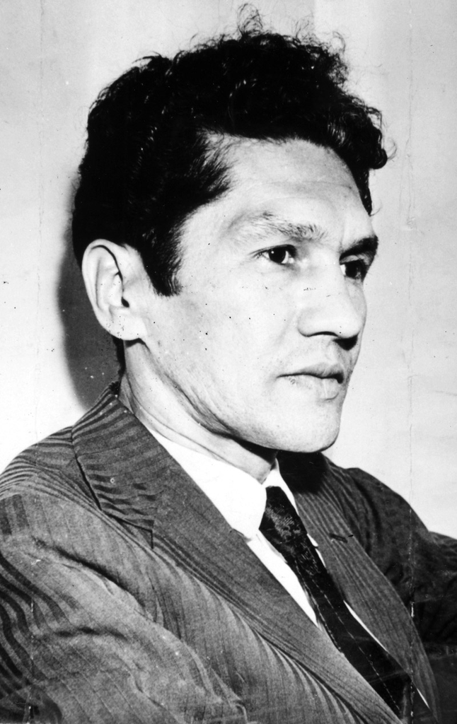

Retrato histórico de Francisco Julião, liderança das Ligas Camponesas.

Francisco Julião e as Ligas Camponesas Arquivo histórico / Domínio Público · lutas agrárias e contexto pré-1964

## Paradigma O Modelo Difusionista na Extensão Rural

Caracterização (Peixoto, 2008) Fluxo unilateral de informações

A extensão rural, especialmente nas fases iniciais, foi marcada pelo **modelo difusionista**:

- Fluxo de informações **unilateral** (extensionista → agricultor)
- Transvestida de **transferência de tecnologia**
- Abordagem “do **topo para baixo**” (Peixoto, 2008)

Efeitos sobre o produtor Consequências no campo

A verticalidade da comunicação gera assimetrias estruturais:

- Agricultor reduzido a **receptor passivo**
- Produtor frequentemente tratado como **“problema a ser solucionado”**
- Limitação da **participação e autonomia** das famílias rurais

**Ruptura necessária:** superar a imposição de pacotes tecnológicos para construir processos educativos e dialógicos no território.

## Comparativo Do Modelo Difusionista à PNATER Participativa

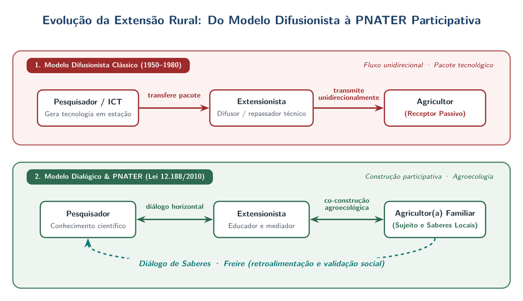

Diagrama comparativo entre o Modelo Difusionista Clássico e o Modelo Dialógico da PNATER.

Evolução dos modelos de extensão rural no Brasil Contraste entre transferência unilateral (1950–1980) e co-construção dialógica prevista na Lei 12.188/2010

## Crítica Problemas da Abordagem Difusionista

Dificuldades para os agricultores (Landini, 2015) Barreiras de apropriação

- Trabalho grupal ou em parcerias
- Aceitação de mudanças disruptivas
- Inovações que não condizem com a realidade local

Dificuldades para os extensionistas Limites de postura técnica

- Persistência de uma abordagem **tecnicista**
- Olhar **autocrítico** dirigido ao agricultor
- Tendência a ver o produtor como **um problema**

**Diagnóstico de Landini (2015):** quando a extensão desconsidera o contexto local, falhas de adequação tecnológica são erroneamente atribuídas à “resistência” do agricultor.

# Agroecologia, Comunicação e Andragogia

## Agroecologia Extensão Rural Agroecológica

**Caporal (2003) — novo significado para “extensão”:**

*“Processo de intervenção de caráter educativo e transformador, baseado em metodologias que permitam o desenvolvimento de uma prática social.”*

Sujeitos da transformação Ação consciente sobre a realidade

Os sujeitos do processo buscam a **construção e sistematização** de conhecimentos que os levem a agir **conscientemente** sobre a realidade agrária e socioambiental.

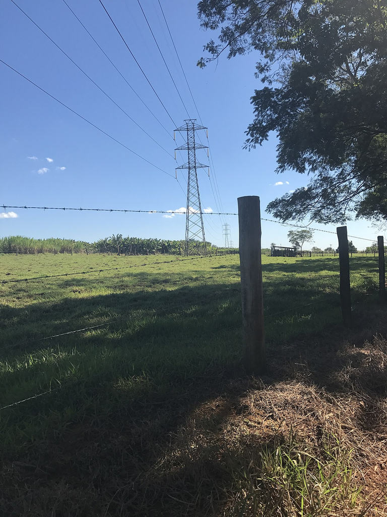

Paisagem de agricultura familiar em área de assentamento rural.

Agricultura familiar em área de assentamento Registro de campo · agroecossistemas familiares e prática social extensionista

## Teorias Abordagens Sistêmicas e Participativas

O surgimento de estruturas **sistêmicas e humanistas** revolucionou a extensão rural (Favero e Sarriera, 2009).

| Teoria | Autor |
| --- | --- |
| **Extensão como Comunicação** | Paulo Freire |
| **Educação Crítica Construtivista** | Jean Piaget |
| **Andragogia** | Malcolm S. Knowles |
| **Pedagogia da Autonomia** | Paulo Freire |

A convergência entre comunicação dialógica, construtivismo e educação de adultos desloca o extensionista do papel de transmissor para o de **mediador pedagógico**.

## Andragogia Andragogia de Knowles na Extensão Rural

A andragogia oferece um quadro centrado no **aprendiz adulto**, valorizando sua experiência prévia e incentivando o **aprendizado autodirigido** (Knowles, 1980).

| Princípio | Aplicação na ATER |
| --- | --- |
| **Necessidade** | Explorar interesses pessoais do produtor |
| **Autonomia** | Promover capacidade de autogestão |
| **Experiência** | Valorizar o saber do agricultor |
| **Motivação** | Técnicos como agentes catalisadores |
| **Orientação na realidade** | Ações que caibam na realidade do produtor |
| **Aplicabilidade** | Proposta real e prática ao produtor |

# PNATER, PRONATER e ATER Digital

## Política PNATER (Lei 12.188/2010) e Estrutura do PRONATER

**Política Nacional de Assistência Técnica e Extensão Rural (Lei 12.188/2010):** voltada para a **melhoria das condições de vida** da população rural, apoiando a modernização da agricultura e estruturando o **PRONATER** em quatro subprogramas (MDA, 2013).

Subprograma 01 Agentes de ATER

Capacitação continuada de **agentes de ATER** para atuação dialógica e participativa.

Subprograma 02 Agricultores Familiares

Capacitação técnica, social e organizativa de **agricultores familiares**.

Subprograma 03 Programas Estaduais

Fomento e fortalecimento dos **programas estaduais de ATER** nos territórios.

Subprograma 04 ATER Setorial

Ações de **ATER Setorial** voltadas a cadeias produtivas e públicos específicos.

**Fonte normativa:** Lei nº 12.188/2010 e Ministério do Desenvolvimento Agrário (MDA, 2013).

## Arquitetura Estrutura PNATER → PRONATER (Lei 12.188/2010)

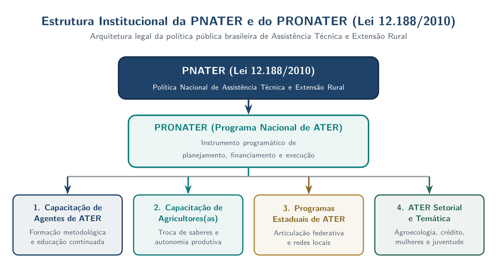

Arquitetura Institucional da PNATER e do PRONATER Política Nacional de ATER (Lei nº 12.188/2010) e seus quatro eixos programáticos no PRONATER

O **PRONATER** operacionaliza a PNATER nos territórios por meio de formação de agentes, capacitação de agricultores familiares, programas estaduais e ações setoriais.

## Diretrizes Princípios da ATER no Brasil

01 · Equidade Inclusão social

Superar discriminação e exclusão histórica no campo.

02 · Sustentabilidade Transição agroecológica

Práticas agroecológicas, quintais produtivos e feiras locais.

03 · Tripé formativo ATER–Pesquisa–Ensino

Educação no campo e transferência articulada de tecnologia.

04 · Diversidade Reconhecimento cultural

Povos originários, quilombolas e pescadores (Lei 11.326/06).

05 · Economia Ocupação e renda

Diversificação produtiva e agregação de valor no território.

06 · Governança Atuação em redes

Cooperação entre instituições e gestão participativa.

## Digital Programa ATER Digital

O **Programa ATER Digital** busca aprimorar a eficácia e o alcance da assistência técnica por meio de **tecnologias digitais**, representando avanço significativo na era da informação.

01 · Acessibilidade Alcance e interatividade

Ampliação da **acessibilidade** e da interatividade nos atendimentos técnicos a distância.

02 · Articulação Diálogo institucional

Aproximação contínua entre agricultores e instituições de extensão rural.

03 · Equidade Inclusão digital

**Inclusão digital** como catalisador para comunidades rurais marginalizadas.

# Síntese e Referências

## Síntese Conclusão: Alcance das Políticas de Extensão Rural

As políticas e programas de extensão rural representam **esforços significativos** dos agricultores em busca de uma ATER estatizada de qualidade.

**Desenvolvimento rural sustentável:** integração entre produção agrícola, conservação ambiental e justiça social.

**Fortalecimento da agricultura familiar:** autonomia produtiva e reconhecimento dos sujeitos do campo.

**Segurança alimentar e nutricional:** oferta diversificada de alimentos saudáveis em circuitos locais e institucionais.

**Redução da pobreza rural:** inclusão produtiva, geração de trabalho e agregação de renda.

**Mitigação das mudanças climáticas:** transição agroecológica e ampliação da resiliência dos agroecossistemas.

## Referências Referências Bibliográficas e Marcos Legais

Legislação e documentos Marcos legais e institucionais

- Brasil. Lei 4.504/64 — Estatuto da Terra (1964)
- Brasil. Lei 5.969/73 — PROAGRO (1973)
- Brasil. Lei 6.126/74 — EMBRATER (1974)
- Brasil. Lei 11.326/06 — Agricultura Familiar (2006)
- Brasil. Lei 12.188/2010 — PNATER/PRONATER (2010)
- MDA. Programa Nacional de ATER — PRONATER (2013)

Literatura científica Referências teóricas

- Caporal, F. R. *Extensão Rural Agroecológica* (2003)
- Favero, E.; Sarriera, J. C. Abordagens sistêmicas e humanistas na extensão rural (2009)
- Knowles, M. S. *A prática moderna da educação de adultos* (1970; 1980)
- Landini, F. *Problemas enfrentados por extensionistas* (2015)
- Peixoto, M. et al. *Extensão rural no Brasil* (2008)